# evaluate_factors_impacting_pedestrian_traffic

**Evaluate Factors Impacting Pedestrian Traffic**

**Authored by:** Brendan Richards, Barkha Javed

**Duration:** 60 mins

**Level:**Beginner **Pre-requisite Skills:**Python

**Scenario**

**As a small business owner, I want to understand how covid affected foot traffic, and how long it might take to return to normal. I'd also like deeper insights into how different activities can impact pedestrian traffic.**

Factors impacting traffic include those listed below, we will be examining some of these in depth:

- Seasonality through temperature, severe weather events, daylight savings, public holidays such as Christmas, school holidays,
- Time of day, day of week
- Major events such as the AFL, concerts and exhibitions
- Proximity to public transport: Trains / Buses / Trams
- Number of local residences
- Number of people travelling into the CBD
- Covid cases and status
- Other venues in proximity - schools, universities, parks, retail outlets, restaurants, bars, clubs, cinemas

**What this Use Case will teach you**

At the end of this use case you will understand how to examine the impact of various factors on pedestrain traffic.

This means learning how to:

- Load and examine the pedestrian sensor locations
- Load and examine the pedestrian counting system - monthly (counts per hour) dataset
- Load and examine the activities dataset
- Load and examine Covid cases, deaths, vaccinations data
- Examine the impact of factors on pedestrian foot traffic
- Use visualisations to share results
- Increase understanding of possible factors impacting foot traffic when building predictive models

**A brief introduction to the datasets used**

Briefly about each dataset and intended use

The exploratory data analysis on Covid case data showing initial findings is available, please refer to [compare pedestrian traffic pre Covid to now](https://github.com/Chameleon-company/MOP-Code/blob/barkhaj-branch/datascience/dataanalysis/Other%20EDA/eda_compare_pedestrian_traffic_precovid_to_now.ipynb)

The exploratory data analysis on day and night showing initial findings is available, please refer to [compare pedestrian traffic day night](https://github.com/Chameleon-company/MOP-Code/blob/barkhaj-branch/datascience/dataanalysis/Other%20EDA/eda_compare_pedestrian_traffic_day_night.ipynb)

**Accessing and Loading data**

```python
#Libraries to be installed
##!pip -q is to give less output
!pip -q install sodapy
!pip -q install seaborn
!pip -q install pandas
!pip -q install matplotlib
!pip -q install numpy
!pip -q install nbconvert
!pip -q install keyboard
!pip -q install geopandas
!pip -q install requests
```

```python
#load libraries
import os
import io
import time
import keyboard
import warnings
warnings.filterwarnings('ignore')
from datetime import datetime
import requests

import numpy as np
import pandas as pd
from sodapy import Socrata

from IPython.core.display import display, HTML
import geopandas as gpd

import plotly.express as px
import seaborn as sns
import matplotlib.pyplot as plt
%matplotlib inline
from matplotlib import style
style.use('ggplot')

#Socrata client connection
client = Socrata('data.melbourne.vic.gov.au', '9UAGAvkem9fqXDhBLElapjazL', None)
```

### Load geospatial Event data

```python
#This is a quick way to import the geospatial 'event' data from the CoM repository
activities_url="https://data.melbourne.vic.gov.au/api/geospatial/txcy-uafv?method=export&format=GeoJSON"
activities_gdf=gpd.read_file(activities_url)
activities_gdf.head(5)
```

|  | start_date | location | activity_id | end_date | status | source_id | notes | classification | small_area | geometry |
| --- | --- | --- | --- | --- | --- | --- | --- | --- | --- | --- |
| 0 | 2022-04-25T00:00:00 | 17-23 Wills StreetMELBOURNE VIC 3000 | SS-1076969-0-110168-ECW-Consent Extended-25042... | 2022-06-05T00:00:00 | Confirmed | ECW-2021-334 | ePathway Consent for works | Structures | Melbourne (CBD) | MULTIPOLYGON (((144.95675 -37.81092, 144.95682... |
| 1 | 2022-01-01T00:00:00 | Therry Street between Victoria Street and Eliz... | WO-728357-1554230-1554230-61-Closed-0101202200... | 2022-06-30T00:00:00 | CONFIRMED | 728357 | - | Traffic Management | Melbourne (CBD) | MULTIPOLYGON (((144.96154 -37.80669, 144.96155... |
| 2 | 2022-05-15T00:00:00 | Canning Street between Dryburgh Street and Shi... | RP-59095-193964-21212-COU-Confirmed-1505202200... | 2022-05-15T00:00:00 | CONFIRMED | 33104 | None | Reserved Parking | North Melbourne | MULTIPOLYGON (((144.94331 -37.79619, 144.94434... |
| 3 | 2022-05-07T00:00:00 | 111-149 Nicholson StreetCARLTON VIC 3053 | SS-1102147-0-107153-ECW-Consent Extended-07052... | 2022-06-02T00:00:00 | Confirmed | ECW-2022-24 | ePathway Consent for works | Structures | Carlton | MULTIPOLYGON (((144.97414 -37.79680, 144.97405... |
| 4 | 2022-03-31T00:00:00 | 24-30 Barkly PlaceCARLTON VIC 3053 | SS-1108795-0-100732-EHD-Permit Issued-31032022... | 2022-07-30T00:00:00 | CONFIRMED | EHD-2021-89/1 | Hoarding | Structures | Carlton | MULTIPOLYGON (((144.96157 -37.80292, 144.96137... |

```python
#Found there are records with value 2921-11-19 00:00:00, exclude these
activities_gdf = activities_gdf.loc[(activities_gdf['end_date'] < '2065-01-01')]

#Pre-processing of that event dataset
activities_gdf.start_date = pd.to_datetime(activities_gdf.start_date, format='%Y-%m-%d')
activities_gdf.end_date = pd.to_datetime(activities_gdf.end_date, format='%Y-%m-%d')
activities_gdf['start_year'] = activities_gdf.start_date.dt.year
activities_gdf['start_month'] = activities_gdf.start_date.dt.month_name()
activities_gdf['start_mdate'] = activities_gdf.start_date.dt.day
activities_gdf['start_time'] = activities_gdf.start_date.dt.hour
activities_gdf['end_year'] = activities_gdf.end_date.dt.year
activities_gdf['end_month'] = activities_gdf.end_date.dt.month_name()
activities_gdf['end_mdate'] = activities_gdf.end_date.dt.day
activities_gdf['end_time'] = activities_gdf.end_date.dt.hour

activities_gdf = activities_gdf.drop(['location', 'source_id', 'small_area','notes', 'status'], axis=1)

activities_gdf['adjacent'] = activities_gdf['geometry'].buffer(0.0005)
activities_gdf['near'] = activities_gdf['geometry'].buffer(0.001)
activities_gdf[["In","Adjacent","Near"]] = None
activities_gdf[["In","Adjacent","Near"]] = activities_gdf[["In","Adjacent","Near"]].astype('object')
```

```python
#Different types of event or activity
activities_gdf.classification.unique()
```

```
array(['Structures', 'Traffic Management', 'Reserved Parking', 'Event',
       'Public Event', 'Private Event'], dtype=object)
```

```python
#look at events that are still current
current_act = activities_gdf[(activities_gdf.classification.isin(['Event','PublicEvent','Sport/Recreation']))
                             &(activities_gdf.end_year >= 2022)]

current_act.head(5)
```

|  | start_date | activity_id | end_date | classification | geometry | start_year | start_month | start_mdate | start_time | end_year | end_month | end_mdate | end_time | adjacent | near | In | Adjacent | Near |
| --- | --- | --- | --- | --- | --- | --- | --- | --- | --- | --- | --- | --- | --- | --- | --- | --- | --- | --- |
| 8 | 2018-03-28 | P-336-4183-4183-9-Warning-280320180000-2803202... | 2028-03-28 | Event | MULTIPOLYGON (((144.98963 -37.81241, 144.98872... | 2018 | March | 28 | 0 | 2028 | March | 28 | 0 | POLYGON ((144.99012 -37.81249, 144.98996 -37.8... | POLYGON ((144.99061 -37.81258, 144.99046 -37.8... | None | None | None |
| 40 | 2018-08-20 | P-355-4031-4031-9-Warning-200820180000-0307202... | 2022-07-03 | Event | MULTIPOLYGON (((144.95501 -37.81144, 144.95502... | 2018 | August | 20 | 0 | 2022 | July | 3 | 0 | POLYGON ((144.95366 -37.81206, 144.95367 -37.8... | POLYGON ((144.95344 -37.81150, 144.95347 -37.8... | None | None | None |
| 73 | 2019-04-02 | P-1816-4225-4225-9-Warning-020420190000-281120... | 2022-11-28 | Event | MULTIPOLYGON (((144.97173 -37.82704, 144.97173... | 2019 | April | 2 | 0 | 2022 | November | 28 | 0 | POLYGON ((144.97218 -37.82674, 144.97218 -37.8... | POLYGON ((144.97266 -37.82659, 144.97269 -37.8... | None | None | None |
| 81 | 2018-08-14 | P-213-4194-4194-9-Warning-140820181130-3007202... | 2025-07-30 | Event | MULTIPOLYGON (((144.96094 -37.80091, 144.96106... | 2018 | August | 14 | 0 | 2025 | July | 30 | 0 | POLYGON ((144.95939 -37.80103, 144.95939 -37.8... | POLYGON ((144.95886 -37.80111, 144.95886 -37.8... | None | None | None |
| 98 | 2022-04-08 | P-5713-3988-3988-8-Reinstatement-080420220000-... | 2022-05-20 | Event | MULTIPOLYGON (((144.97031 -37.80619, 144.97031... | 2022 | April | 8 | 0 | 2022 | May | 20 | 0 | POLYGON ((144.96927 -37.80574, 144.96927 -37.8... | POLYGON ((144.96881 -37.80595, 144.96880 -37.8... | None | None | None |

### Load pedestrian traffic sensor location data

```python
#Pedestrian sensor location data
sensor_data_id = "h57g-5234"
results = client.get(sensor_data_id)
sensor_location = pd.DataFrame.from_records(results)
#sensor_location.head(5)

sensor_location[['latitude', 'longitude']] = sensor_location[['latitude', 'longitude']].astype(float)
sensor_location = sensor_location.drop('location',axis=1)

#View sensor data
sensor_location.info()
sensor_location.head(5)
```

```
<class 'pandas.core.frame.DataFrame'>
RangeIndex: 91 entries, 0 to 90
Data columns (total 10 columns):
 #   Column              Non-Null Count  Dtype
---  ------              --------------  -----
 0   sensor_id           91 non-null     object
 1   sensor_description  91 non-null     object
 2   sensor_name         91 non-null     object
 3   installation_date   91 non-null     object
 4   status              91 non-null     object
 5   note                10 non-null     object
 6   latitude            91 non-null     float64
 7   longitude           91 non-null     float64
 8   direction_1         78 non-null     object
 9   direction_2         78 non-null     object
dtypes: float64(2), object(8)
memory usage: 7.2+ KB
```

|  | sensor_id | sensor_description | sensor_name | installation_date | status | note | latitude | longitude | direction_1 | direction_2 |
| --- | --- | --- | --- | --- | --- | --- | --- | --- | --- | --- |
| 0 | 16 | Australia on Collins | Col270_T | 2009-03-30T00:00:00.000 | R | Device moved to location ID 53 (22/09/2015) | -37.815734 | 144.965210 | NaN | NaN |
| 1 | 50 | Faraday St-Lygon St (West) | Lyg309_T | 2017-11-30T00:00:00.000 | A | NaN | -37.798082 | 144.967210 | South | North |
| 2 | 73 | Bourke St - Spencer St (South) | Bou655_T | 2020-10-02T00:00:00.000 | I | NaN | -37.816957 | 144.954154 | East | West |
| 3 | 66 | State Library - New | QVN_T | 2020-04-06T00:00:00.000 | A | NaN | -37.810578 | 144.964443 | South | North |
| 4 | 59 | Building 80 RMIT | RMIT_T | 2019-02-13T00:00:00.000 | A | NaN | -37.808256 | 144.963049 | South | North |

### Load pedestrian traffic hourly counts data

```python
#Pedestrian foot count data
#Uncomment the below to open data source, download sensor data, and store it as a csv locally.
sensor_data_id = "b2ak-trbp"
#results = client.get(sensor_data_id, limit=7000000)
#ds_traffic = pd.DataFrame.from_records(results)
#ds_traffic.to_csv('sensor_traffic.csv', index=False)

sensor_traffic = pd.read_csv('sensor_traffic.csv')
sensor_traffic.info()

print(f'\nThe shape of dataset is {sensor_traffic.shape}. \n')
print('Below are the first few rows of this dataset: ')
sensor_traffic.head(10)
```

```
<class 'pandas.core.frame.DataFrame'>
RangeIndex: 4562230 entries, 0 to 4562229
Data columns (total 10 columns):
 #   Column         Dtype
---  ------         -----
 0   id             int64
 1   date_time      object
 2   year           int64
 3   month          object
 4   mdate          int64
 5   day            object
 6   time           int64
 7   sensor_id      int64
 8   sensor_name    object
 9   hourly_counts  int64
dtypes: int64(6), object(4)
memory usage: 348.1+ MB

The shape of dataset is (4562230, 10).

Below are the first few rows of this dataset:
```

|  | id | date_time | year | month | mdate | day | time | sensor_id | sensor_name | hourly_counts |
| --- | --- | --- | --- | --- | --- | --- | --- | --- | --- | --- |
| 0 | 2887628 | 2019-11-01T17:00:00.000 | 2019 | November | 1 | Friday | 17 | 34 | Flinders St-Spark La | 300 |
| 1 | 2887629 | 2019-11-01T17:00:00.000 | 2019 | November | 1 | Friday | 17 | 39 | Alfred Place | 604 |
| 2 | 2887630 | 2019-11-01T17:00:00.000 | 2019 | November | 1 | Friday | 17 | 37 | Lygon St (East) | 216 |
| 3 | 2887631 | 2019-11-01T17:00:00.000 | 2019 | November | 1 | Friday | 17 | 40 | Lonsdale St-Spring St (West) | 627 |
| 4 | 2887632 | 2019-11-01T17:00:00.000 | 2019 | November | 1 | Friday | 17 | 36 | Queen St (West) | 774 |
| 5 | 2887633 | 2019-11-01T17:00:00.000 | 2019 | November | 1 | Friday | 17 | 29 | St Kilda Rd-Alexandra Gardens | 644 |
| 6 | 2887634 | 2019-11-01T17:00:00.000 | 2019 | November | 1 | Friday | 17 | 42 | Grattan St-Swanston St (West) | 453 |
| 7 | 2887635 | 2019-11-01T17:00:00.000 | 2019 | November | 1 | Friday | 17 | 43 | Monash Rd-Swanston St (West) | 387 |
| 8 | 2887636 | 2019-11-01T17:00:00.000 | 2019 | November | 1 | Friday | 17 | 44 | Tin Alley-Swanston St (West) | 27 |
| 9 | 2887637 | 2019-11-01T17:00:00.000 | 2019 | November | 1 | Friday | 17 | 35 | Southbank | 2691 |

### Merge sensor and location data

```python
#Add date column
sensor_traffic['date'] = pd.to_datetime(sensor_traffic.date_time).dt.date

#Add day of week column
sensor_traffic['dow'] = pd.to_datetime(sensor_traffic.date_time).dt.day_of_week

#convert sensor_id to integer
sensor_traffic['sensor_id']=sensor_traffic['sensor_id'].astype(int)
sensor_location['sensor_id']=sensor_location['sensor_id'].astype(int)

# Mesh pedestrian sensor location and foot traffic datasets
sensor_ds = pd.merge(sensor_traffic, sensor_location, on='sensor_id')

#Simply using the year to differentiate all the years prior to 2020 as before Covid, and post 2019 Covid traffic to now
sensor_ds['pre2020_hourly_counts'] = np.where(sensor_ds['year']<=2019,sensor_ds['hourly_counts'] , 0)
sensor_ds['post2019_hourly_counts'] = np.where(sensor_ds['year']>2019,sensor_ds['hourly_counts'] , 0)

#Add column for day or night traffic
#Add column for day (5am to 5pm) or night (6pm to 4am) traffic
sensor_ds['day_counts']   = np.where(((sensor_ds['time']>4)  & (sensor_ds['time']<18)),sensor_ds['hourly_counts'] , 0)
sensor_ds['night_counts'] = np.where(sensor_ds['day_counts']==0,sensor_ds['hourly_counts'], 0)

sensor_ds.describe()
```

|  | id | year | mdate | time | sensor_id | hourly_counts | dow | latitude | longitude | pre2020_hourly_counts | post2019_hourly_counts | day_counts | night_counts |
| --- | --- | --- | --- | --- | --- | --- | --- | --- | --- | --- | --- | --- | --- |
| count | 4.562230e+06 | 4.562230e+06 | 4.562230e+06 | 4.562230e+06 | 4.562230e+06 | 4.562230e+06 | 4.562230e+06 | 4.562230e+06 | 4.562230e+06 | 4.562230e+06 | 4.562230e+06 | 4.562230e+06 | 4.562230e+06 |
| mean | 2.281708e+06 | 2.017333e+03 | 1.574675e+01 | 1.146982e+01 | 2.735892e+01 | 4.926315e+02 | 3.001057e+00 | -3.781341e+01 | 1.449621e+02 | 3.986104e+02 | 9.402113e+01 | 3.575141e+02 | 1.351174e+02 |
| std | 1.317918e+06 | 3.580411e+00 | 8.799595e+00 | 6.938244e+00 | 1.978492e+01 | 7.475427e+02 | 2.000297e+00 | 6.212739e-03 | 8.555391e-03 | 7.386555e+02 | 2.969237e+02 | 7.097362e+02 | 3.894963e+02 |
| min | 1.000000e+00 | 2.009000e+03 | 1.000000e+00 | 0.000000e+00 | 1.000000e+00 | 0.000000e+00 | 0.000000e+00 | -3.782402e+01 | 1.449297e+02 | 0.000000e+00 | 0.000000e+00 | 0.000000e+00 | 0.000000e+00 |
| 25% | 1.140558e+06 | 2.015000e+03 | 8.000000e+00 | 5.000000e+00 | 1.100000e+01 | 4.300000e+01 | 1.000000e+00 | -3.781863e+01 | 1.449587e+02 | 0.000000e+00 | 0.000000e+00 | 0.000000e+00 | 0.000000e+00 |
| 50% | 2.281116e+06 | 2.018000e+03 | 1.600000e+01 | 1.100000e+01 | 2.400000e+01 | 1.770000e+02 | 3.000000e+00 | -3.781381e+01 | 1.449651e+02 | 5.400000e+01 | 0.000000e+00 | 2.400000e+01 | 0.000000e+00 |
| 75% | 3.421673e+06 | 2.020000e+03 | 2.300000e+01 | 1.700000e+01 | 4.200000e+01 | 6.010000e+02 | 5.000000e+00 | -3.781102e+01 | 1.449669e+02 | 4.350000e+02 | 3.000000e+01 | 3.500000e+02 | 5.900000e+01 |
| max | 4.567701e+06 | 2.022000e+03 | 3.100000e+01 | 2.300000e+01 | 8.700000e+01 | 1.597900e+04 | 6.000000e+00 | -3.779432e+01 | 1.449747e+02 | 1.597900e+04 | 1.443700e+04 | 1.161200e+04 | 1.597900e+04 |

### Load Covid dataset and merge with pedestrian traffic

```python
#download covid dataset
url = "https://raw.githubusercontent.com/M3IT/COVID-19_Data/master/Data/COVID_Data_Hub_State.csv"
download = requests.get(url).content
df_hub= pd.read_csv(io.StringIO(download.decode('utf-8')))
```

```python
#look at VIC data
options = ['Victoria']

# selecting rows based on condition
ds = df_hub[df_hub['administrative_area_level_2'].isin(options)]
ds_hub = ds[['date','confirmed','deaths','positives','people_vaccinated','people_fully_vaccinated','administrative_area_level_2']]

#log transform - may want to apply to more variables
ds_hub['confirmed_log']=np.log(np.log(ds_hub['confirmed']))

print (ds_hub.head(), '\n')
print (ds_hub.describe(), '\n')
print (ds_hub.info())
print("\nTotal number of missing values is","{:,d}".format(ds_hub.isnull().values.sum()))
print("\nColumn-wise distribution of null values\n",ds_hub.isnull().sum())
```

```
          date  confirmed  deaths  positives  people_vaccinated  \
6   2020-01-25          1       0        0.0                  0
14  2020-01-26          1       0        0.0                  0
22  2020-01-27          1       0        0.0                  0
30  2020-01-28          1       0        0.0                  0
38  2020-01-29          3       0        0.0                  0

    people_fully_vaccinated administrative_area_level_2  confirmed_log
6                         0                    Victoria           -inf
14                        0                    Victoria           -inf
22                        0                    Victoria           -inf
30                        0                    Victoria           -inf
38                        0                    Victoria       0.094048

          confirmed       deaths     positives  people_vaccinated  \
count  1.015000e+03  1015.000000  1.015000e+03       1.015000e+03
mean   5.604687e+05  1568.618719  5.604686e+05       1.964970e+06
std    9.038921e+05  1634.935545  9.038922e+05       2.302546e+06
min    1.000000e+00     0.000000  0.000000e+00       0.000000e+00
25%    2.021450e+04   809.000000  2.021450e+04       0.000000e+00
50%    2.066800e+04   823.000000  2.066800e+04       1.150770e+05
75%    1.014670e+06  2434.000000  1.014670e+06       5.059583e+06
max    2.648933e+06  5847.000000  2.648933e+06       5.192387e+06

       people_fully_vaccinated  confirmed_log
count             1.015000e+03    1015.000000
mean              1.707556e+06           -inf
std               2.247097e+06            NaN
min               0.000000e+00           -inf
25%               0.000000e+00       2.293964
50%               0.000000e+00       2.296199
75%               4.959754e+06       2.626845
max               5.110718e+06       2.693929

<class 'pandas.core.frame.DataFrame'>
Int64Index: 1015 entries, 6 to 8118
Data columns (total 8 columns):
 #   Column                       Non-Null Count  Dtype
---  ------                       --------------  -----
 0   date                         1015 non-null   object
```

[output cut: 8 more lines]

```
memory usage: 71.4+ KB
None

Total number of missing values is 0

Column-wise distribution of null values
 date                           0
confirmed                      0
deaths                         0
positives                      0
people_vaccinated              0
people_fully_vaccinated        0
administrative_area_level_2    0
confirmed_log                  0
dtype: int64
```

```python
#check merge column is of same data type, convert if required
ds_hub['date'] = pd.to_datetime(ds_hub['date'], infer_datetime_format=True)
sensor_ds['date'] = pd.to_datetime(sensor_ds['date'], infer_datetime_format=True)

# Mesh Covid and foot traffic datasets
sensor_covid = pd.merge(sensor_ds, ds_hub, on='date')

#drop columns
ds_hub.info()
sensor_ds.info()
```

```
<class 'pandas.core.frame.DataFrame'>
Int64Index: 1015 entries, 6 to 8118
Data columns (total 8 columns):
 #   Column                       Non-Null Count  Dtype
---  ------                       --------------  -----
 0   date                         1015 non-null   datetime64[ns]
 1   confirmed                    1015 non-null   int64
 2   deaths                       1015 non-null   int64
 3   positives                    1015 non-null   float64
 4   people_vaccinated            1015 non-null   int64
 5   people_fully_vaccinated      1015 non-null   int64
 6   administrative_area_level_2  1015 non-null   object
 7   confirmed_log                1015 non-null   float64
dtypes: datetime64[ns](1), float64(2), int64(4), object(1)
memory usage: 71.4+ KB
```

[output cut: 32 more lines]

**Examine Datasets**

### View Activities, Events by sensor location

```python
#This map just demonstrates the 'geometry', 'adjacent' and 'near' polygons.
#This is so we can compare whether a sensor is inside an event's geometry, adjacent to it, or near to it.

style1 = {'fillColor': 'cyan', 'color': 'cyan'}
style2 = {'fillColor': 'orange', 'color': 'orange'}
style3 = {'fillColor': 'yellow', 'color': 'yellow'}

import folium

#Create a map object centered on Melbourne
map = folium.Map(location=[-37.81216592937499,
                           144.961812290625],
                          zoom_start=14)

#Add the current events to the map
folium.GeoJson(data=current_act.geometry, style_function=lambda x:style1).add_to(map)
folium.GeoJson(data=current_act.adjacent, style_function=lambda x:style2).add_to(map)
folium.GeoJson(data=current_act.near, style_function=lambda x:style3).add_to(map)

#Add all sensor locations
location_data = sensor_location
sensor_ds
for i in range(0,len(location_data)):
   folium.Marker(
      location=[location_data.iloc[i]['latitude'], location_data.iloc[i]['longitude']],
      popup=location_data.iloc[i]['sensor_description']
   ).add_to(map)

map
```

Make this Notebook Trusted to load map: File -> Trust Notebook

[interactive chart not shown]

### Examine Pedestrian Traffic by Season, time of day and day of week

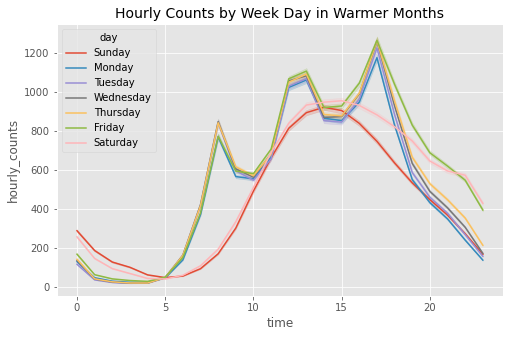

```python
#Plot hourly counts in the warmer months
hue_order = ['Sunday', 'Monday', 'Tuesday', 'Wednesday', 'Thursday', 'Friday', 'Saturday']

plt.figure(figsize=(8,5))
axs = sns.lineplot(x='time', y='hourly_counts', hue='day', hue_order = hue_order,
             data = sensor_ds[sensor_ds.month.isin(['September', 'October', 'November', 'December', 'January'
                                                    , 'February', 'March', 'April'])])

axs.set_title('Hourly Counts by Week Day in Warmer Months', size=14)
plt.show()
```

```python
#Plot hourly counts in the cooler months
plt.figure(figsize=(8,5))
axs = sns.lineplot(x='time', y='hourly_counts', hue='day', hue_order = hue_order,
             #not in warmer months
             data = sensor_ds[~sensor_ds.month.isin(['September', 'October', 'November', 'December', 'January'
                                                    , 'February', 'March', 'April'])])
axs.set_title('Hourly Counts by Week Day in Cooler Months', size=14)
plt.show()
```

[output not shown]

```python
#Counts in all months
plt.figure(figsize=(8,5))
axs = sns.lineplot(x='time', y='hourly_counts', hue = 'day', hue_order = hue_order,
             data = sensor_ds)
axs.set_title('Hourly Counts by Week Day - All Months in a Year', size=14)
plt.show()
```

[output not shown]

**Examine Datasets**

**Congratulations!**

You now know a bit more, about some of the factors impacting pdestrian traffic.

Next steps, you may want to explore an indepth interactive [analysis on the impact and effect of events](https://master-mop-busaytgm.ts.gateway.dev/use-cases/event-disruption) such as the AFL, Grand Prix on pedestrian traffic.

Predicting when pedestrian activity will increase to pre 2020 volumes is a complex task. There are many factors to consider. Hopefully the factors discussed here are useful, and can potentially be included when creating predictive models.

For a closer look at some of the existing datasets and usescases please visit the City of Melbourne Open Data Site.

**References**

City of Melbourne Open Data Team, 2014 - 2021,'Pedestrian Counting System - Monthly (counts per hour)', City of Melbourne, date retrieved 11 Aug 2022, https://dev.socrata.com/foundry/data.melbourne.vic.gov.au/b2ak-trbp

City of Melbourne Open Data Team, 2014 - 2021,'Pedestrian Counting System - Sensor Locations', City of Melbourne, date retrieved 26 Aug 2022, https://data.melbourne.vic.gov.au/Transport/Pedestrian-Counting-System-Sensor-Locations/h57g-5234

O'Brien J, et al., 2020, 'Covid 19 in Australia', covid19data.com.au, date retrieved 20 Aug 2022, https://www.covid19data.com.au/

```python
#save notebook, required so that step to convert to html, writes latest results to file
# may need to adapt for other OS, this is for Windows
keyboard.press_and_release('ctrl+s')

!jupyter nbconvert  evaluate_factors_impacting_pedestrian_traffic.ipynb --to html
```